# Air Quality in Washington

Group 5

For our final project, we wanted to explore the relationship between air quality, race and the average household income per county. By looking at these three factors we are investigating whether income and race has an affect on both overall air quality and on the types of pollutants present.

Whitman County had the greatest number of good quality days with 359 days. While Klickitat County had the fewest good quality days at 120 days.

# Air Quality

The Air Quality Index runs from 0 to 500, the lower the value, the better the air quality. AQI values below 50 are considered good, values over 100 can be unhealthy for sensitive groups, while values over 300 are considered hazardous. During the 2020 fire season, the Georgetown neighborhood of Seattle recorded an AQI of 314!

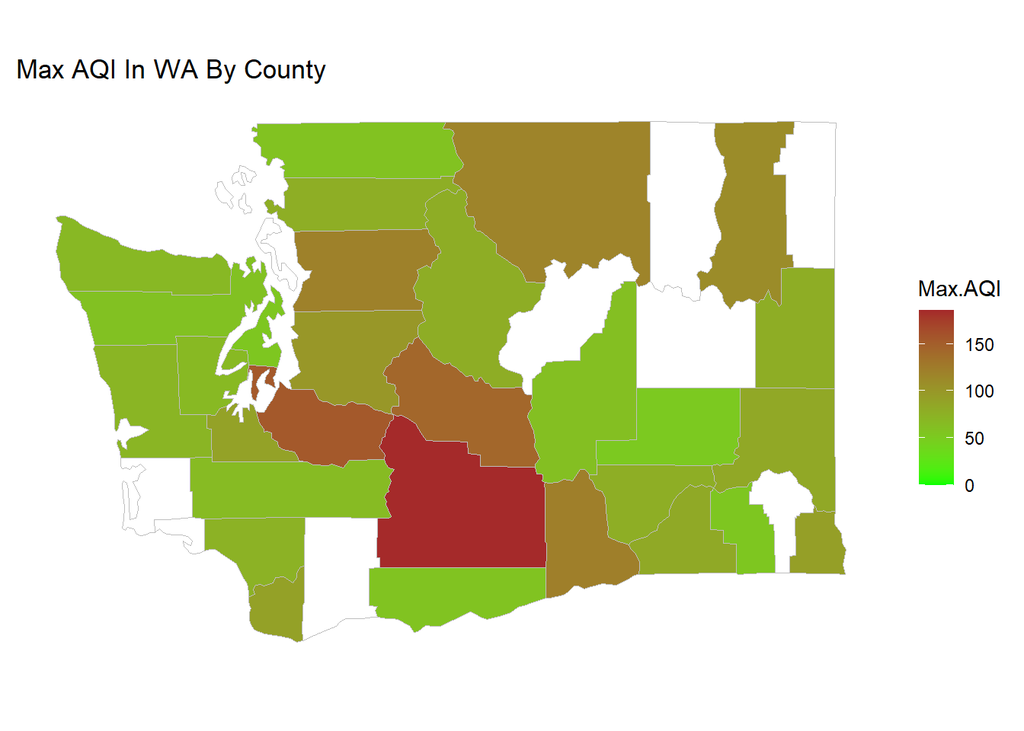

As the first part of our analysis, we mapped out the maximum Air Quality Index value for each county in Washington. This shows us where air quality reached the worst conditions. Considering AQI is not calculated per capita, we were surprised to find that Yakima County recorded the highest AQI in Washington despite its relatively low population. As we continue to work through the data, we will look to see which pollutants in particular are affecting these numbers.

### WA Top 10 90th Percentile AQI Score By County

| County | 90th Percentile AQI |
| --- | --- |
| Yakima | 71 |
| Okanogan | 68 |
| Stevens | 60 |
| Kittitas | 58 |
| King | 56 |
| Snohomish | 56 |
| Pierce | 54 |
| Spokane | 54 |
| Asotin | 51 |
| Benton | 51 |

# Air Pollution

The Air Quality Index tracks 5 major sources of air pollution, ground-level ozone (O3), particle pollution, carbon monoxide (CO), sulfur dioxide (SO3) and nitrogen dioxide (NO2). Each of these pollutants is federally regulated by the Clean Air Act.

### King County WA Pollutant PPM Means in 2015

| County | Mean NO2 (ppm) | Mean O3 (ppm) | Mean SO2 (ppm) | Mean CO (ppm) |
| --- | --- | --- | --- | --- |
| King | 9.753787 | 0.0214056 | 0.8115973 | 0.2043828 |

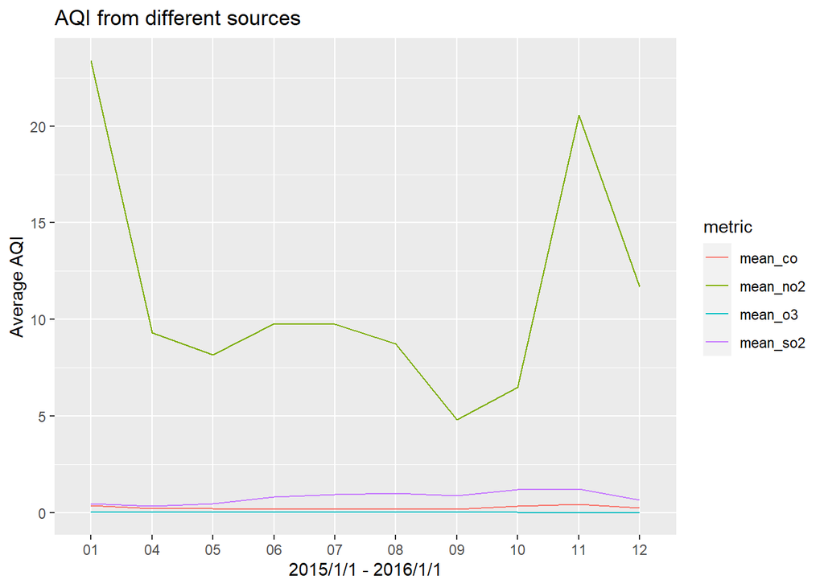

# Household

Next, we wanted to see if there was a correlation between the air quality and the majority race and income for the county.

### What and where is the maximum income reported each year?

| Year | Household.Income.by.Race | Geography |
| --- | --- | --- |
| 2018 | 95009 | King County, WA |
| 2017 | 89675 | King County, WA |
| 2016 | 86095 | King County, WA |
| 2015 | 81916 | King County, WA |
| 2014 | 75834 | King County, WA |
| 2013 | 71834 | King County, WA |

As the most densely populated county, King County tops the list of highest income.

### WA Mean Household Income in 2018 By Race

Next, we charted the annual household income by race.

| Race | Mean Income |
| --- | --- |
| Pacific Islander | 79600.56 |
| Asian | 74732.62 |
| Two Or More | 69992.47 |
| White Non-Hispanic | 69162.00 |
| White | 67728.00 |
| Native American | 60120.50 |
| Black | 57840.00 |
| Hispanic | 52275.80 |
| Other | 51939.00 |

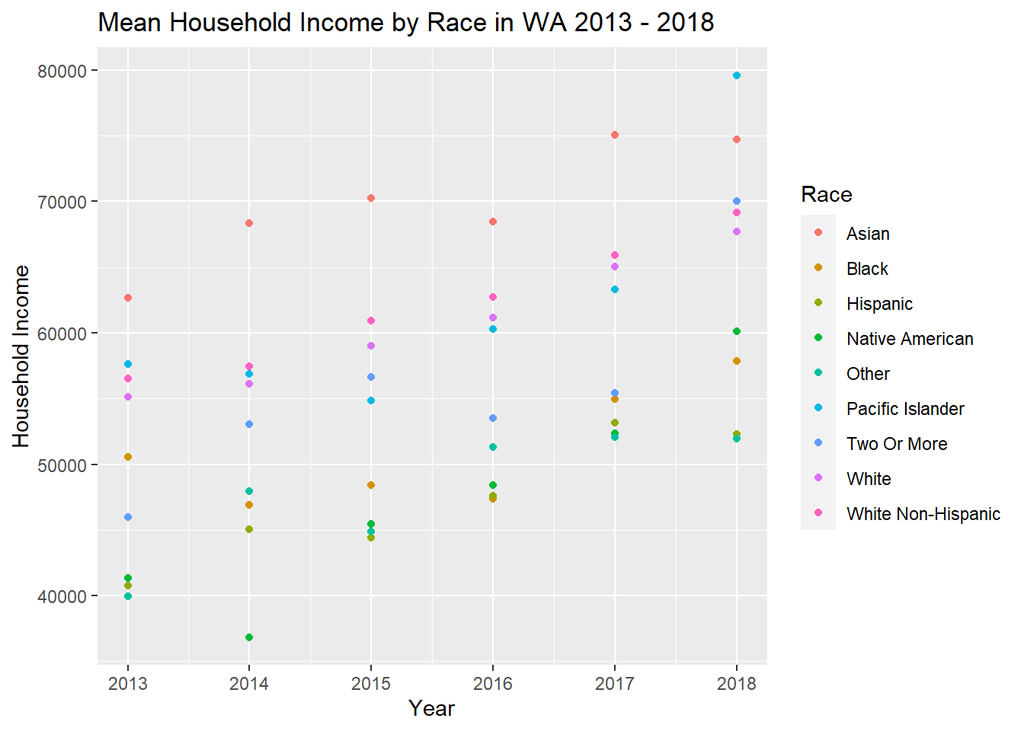

Finally, we charted income by county per year. By comparing the income levels across counties, we’re looking for potential correlations between air quality and income. Our next steps will be to pair this information with air quality.

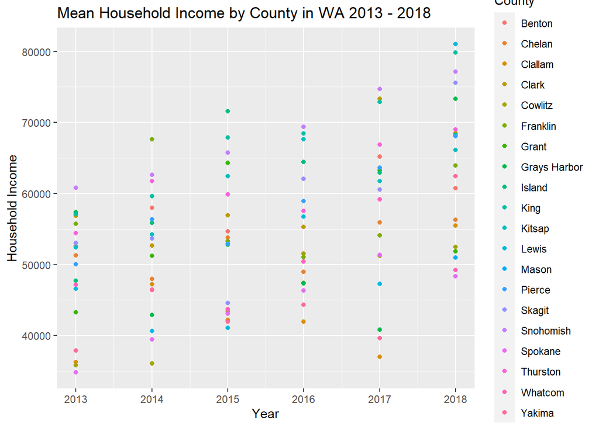